# L21 - Nonlinear Regression

## Lecture Goals

- Learn how to
  - Model *nonlinear* relationships
  - Perform *nonparametric* regression w/ *basis functions*
  - Use nonlinear models for prediction
- Readings
  - [ISLR](http://www-bcf.usc.edu/~gareth/ISL/) ch 7.1-3

## Nonlinear Relationships

- Model response as \(Y = f(X) + \epsilon\), where \(f(\cdot)\) is *nonlinear* function

Two ways to estimate \(f(\cdot)\)

- **Parametric**: assume form of \(f(\cdot)\) is known (e.g. exponential, quadratic), and tune fit with parameters
  - E.g. polynomial/logarithmic regression (transformations)
- **Nonparametric**: minimal assumptions, more flexible forms for \(f(\cdot)\)

## Parametric Model

- Gapminder data, *logarithmic* regression \[Y \sim \alpha + \beta \log(X) \]

```r
gap07 %>% mutate( log_GDP = log(gdpPercap) ) %>%
  lm( lifeExp ~ log_GDP, data = .) %>% tidy()
## # A tibble: 2 x 5
##   term        estimate std.error statistic  p.value
##   <chr>          <dbl>     <dbl>     <dbl>    <dbl>
## 1 (Intercept)     4.95     3.86       1.28 2.02e- 1
## 2 log_GDP         7.20     0.442     16.3  4.12e-34
```

## Parametric Model

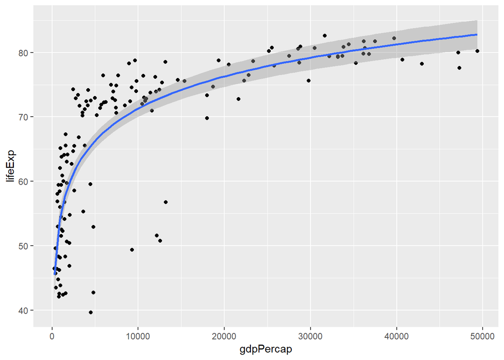

## Nonparametric Regression

- Fit *flexible* model that can take different forms

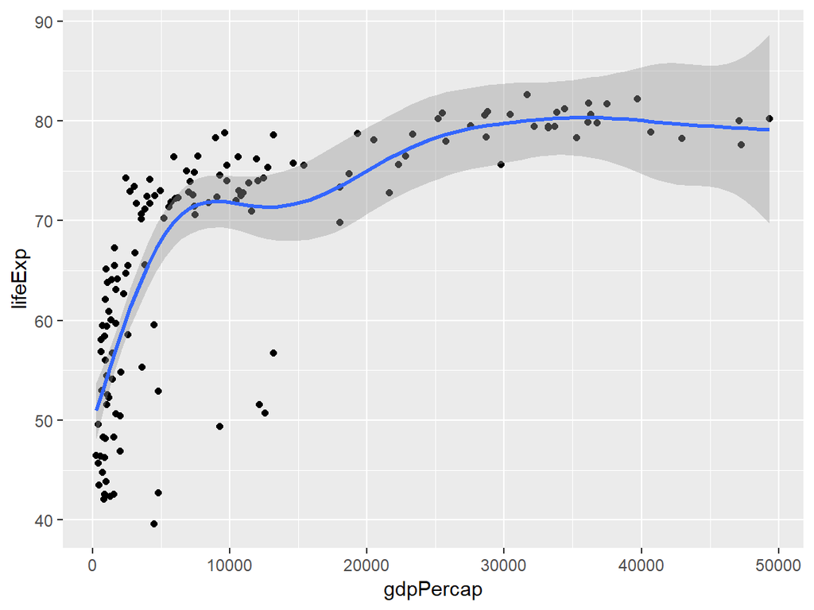

```r
gap07 %>% ggplot( aes(y=lifeExp, x=gdpPercap) ) +
  geom_point() + geom_smooth(method = "gam", formula = y ~ s(x))
```

## Basis Functions

- Certain functions can be expressed as compositions of simpler *basis functions*
  - E.g. *polynomial* is combination of powers of \(x\) \[f(x) = \beta_0 + \beta_1 x + \ldots \beta_q x^q\]
- More generally, for set of basis functions \(\{h_i(\cdot)\}\) \[f(x) = \beta_0 + \beta_1 h_1(x) + \ldots + \beta_m h_m(x)\]
- Fit similarly to multiple regression on basis functions
  - Number/choice of basis functions can **depend on data**

## Example

- Cubic regression

```r
gap07 %>%
  mutate( X1 = gdpPercap, X2 = X1^2, X3 = X1^3) %>%
  lm( lifeExp ~ X1 + X2 +X3, data = .) %>% tidy()
## # A tibble: 4 x 5
##   term         estimate std.error statistic  p.value
##   <chr>           <dbl>     <dbl>     <dbl>    <dbl>
## 1 (Intercept)  5.30e+ 1  1.31e+ 0     40.4  2.33e-78
## 2 X1           2.73e- 3  3.55e- 4      7.69 2.47e-12
## 3 X2          -9.27e- 8  1.99e- 8     -4.65 7.76e- 6
## 4 X3           1.01e-12  3.00e-13      3.37 9.83e- 4
```

## Example

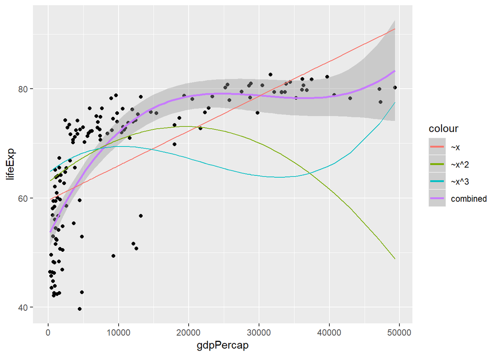

## Smooth Nonparametric Regression

- *Smooth* nonlinear functions can be represented by *local* polynomial bases called splines

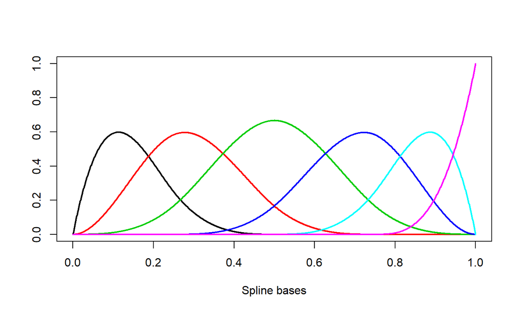

## Generalised Additive Model

- **Generalised additive model (GAM)** describes \(Y\) as sum of (smooth) functions of \(X\)'s  
  \[Y \sim s_1(X_1) + s_2(X_2) + \ldots\]
- `gam()` function in `mgcv` package
  - formula similar to `lm()`
  - use `s()` for *smooth* function (spline-based)
  - include linear or categorial terms

```r
library(mgcv)
gam_out = gam( lifeExp ~ s(gdpPercap) + continent, data = gap07)
```

## Example

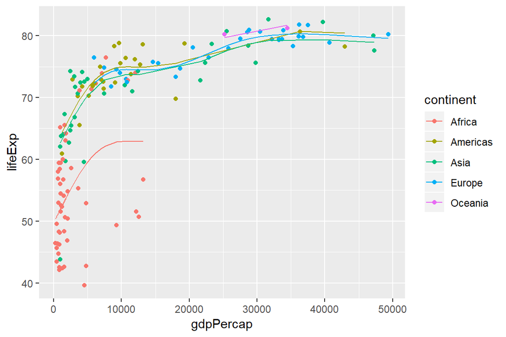

```r
gap07 %>% mutate( pred = predict( gam_out, gap07 ) ) %>%
  ggplot( aes(y=lifeExp, x=gdpPercap, col = continent) ) +
  geom_point() + geom_line( aes(y = pred) )
```

## Regression Trees

- **Regression tree** models \(Y\) as (multivariate) *step function* of \(X\)'s
  - *Non-smooth*, nonparametric model

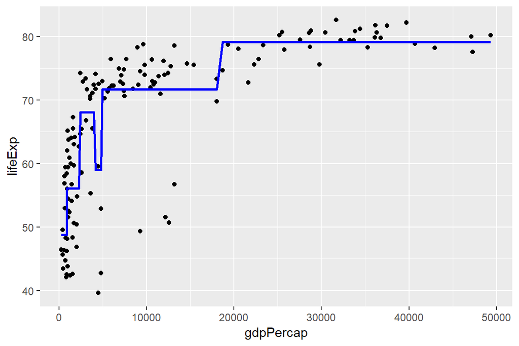

## Example

- Trees can seamlessly accomodate categorical \(X\)'s

```r
library(rpart)
tree = rpart( lifeExp ~ gdpPercap + continent, data = gap07)
```

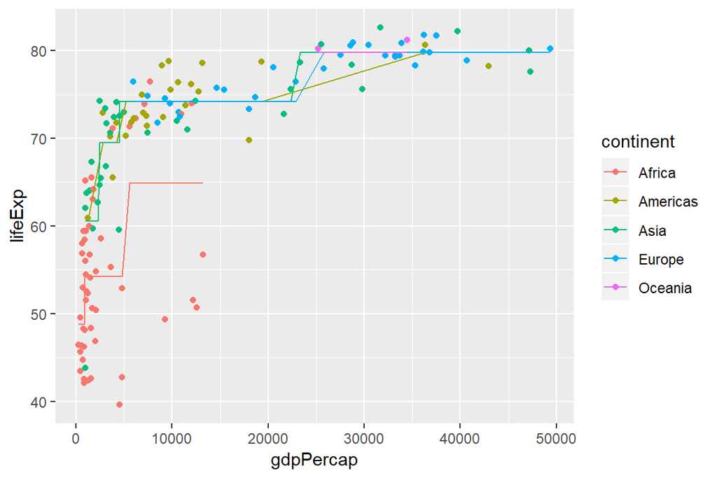

## Example

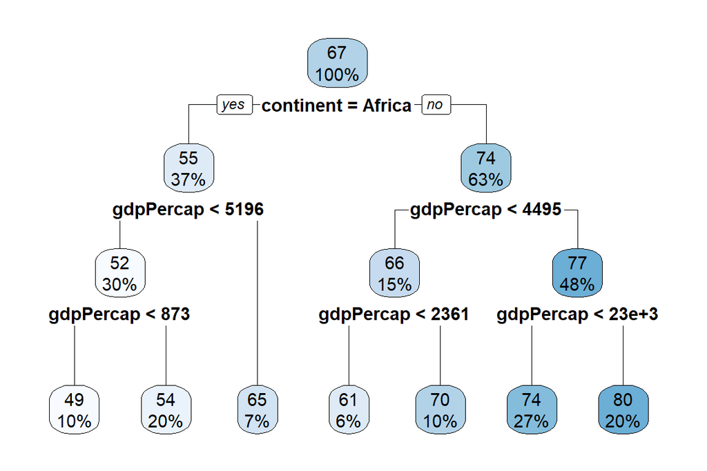

```r
library(rpart.plot); rpart.plot(tree)
```

## Overfitting

- Nonparametric models are prone to *overfitting*
  - Too much flexibility can harm out-of-sample performance

```r
tree = rpart( lifeExp ~ gdpPercap, data = gap07,
       control = rpart.control(cp = 0, minbucket=3))
```

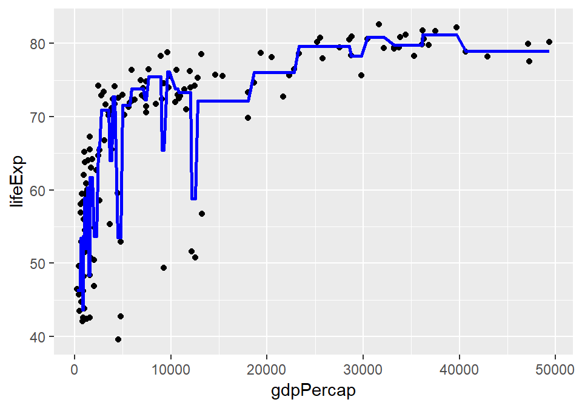

## Predictions

- Model predictions generated with `predict()`
  - Works with *any* nonparametric model
- In-sample performance tends to too optimistic
  - Under-estimate standard deviation of prediction errors
- Use *test set* to estimate out-of-sample performance